# SYS 2202 final project

Nicholas Wu (nrw5cq)

4/14/2021

# Part 1: Spatio-temporal heatmapping of cases and deaths across the contiguous US

- Question: “How have COVID hotspots changed over time?”
- Goal: Use animated choropleth maps to investigate how new cases and new deaths change over time intervals.
  - We are interested in broad trends in states. Using a state-level choropleth map is a readily digestible way of seeing how the case and death data change in the US over time.

## Data cleaning

```r
library(tidyverse)
library(lubridate)
```

- The [COVID-19 Data Repository by CSSE at JHU](https://github.com/CSSEGISandData/COVID-19) was used.
  - Specifically, the time-series csvs were used.
- Retrieve the most recent from the GitHub.

```r
JHUdata_cases <- read_csv("https://github.com/CSSEGISandData/COVID-19/raw/master/csse_covid_19_data/csse_covid_19_time_series/time_series_covid19_confirmed_US.csv")

JHUdata_deaths <- read_csv("https://github.com/CSSEGISandData/COVID-19/raw/master/csse_covid_19_data/csse_covid_19_time_series/time_series_covid19_deaths_US.csv")
```

- Both datasets have the same structure that is somewhat problematic.
  - The dates are column headings rather than grouped into a single variable.
  - The dataset contains county-level data that will be cleaned when we do state-level plotting.

```r
JHUdata_deaths %>% head()
```

```
## # A tibble: 6 x 462
##      UID iso2  iso3  code3  FIPS Admin2 Province_State Country_Region   Lat
##    <dbl> <chr> <chr> <dbl> <dbl> <chr>  <chr>          <chr>          <dbl>
## 1 8.40e7 US    USA     840  1001 Autau… Alabama        US              32.5
## 2 8.40e7 US    USA     840  1003 Baldw… Alabama        US              30.7
## 3 8.40e7 US    USA     840  1005 Barbo… Alabama        US              31.9
## 4 8.40e7 US    USA     840  1007 Bibb   Alabama        US              33.0
## 5 8.40e7 US    USA     840  1009 Blount Alabama        US              34.0
## 6 8.40e7 US    USA     840  1011 Bullo… Alabama        US              32.1
## # … with 453 more variables: Long_ <dbl>, Combined_Key <chr>, Population <dbl>,
## #   `1/22/20` <dbl>, `1/23/20` <dbl>, `1/24/20` <dbl>, `1/25/20` <dbl>,
## #   `1/26/20` <dbl>, `1/27/20` <dbl>, `1/28/20` <dbl>, `1/29/20` <dbl>,
## #   `1/30/20` <dbl>, `1/31/20` <dbl>, `2/1/20` <dbl>, `2/2/20` <dbl>,
## #   `2/3/20` <dbl>, `2/4/20` <dbl>, `2/5/20` <dbl>, `2/6/20` <dbl>,
## #   `2/7/20` <dbl>, `2/8/20` <dbl>, `2/9/20` <dbl>, `2/10/20` <dbl>,
## #   `2/11/20` <dbl>, `2/12/20` <dbl>, `2/13/20` <dbl>, `2/14/20` <dbl>,
## #   `2/15/20` <dbl>, `2/16/20` <dbl>, `2/17/20` <dbl>, `2/18/20` <dbl>,
## #   `2/19/20` <dbl>, `2/20/20` <dbl>, `2/21/20` <dbl>, `2/22/20` <dbl>,
## #   `2/23/20` <dbl>, `2/24/20` <dbl>, `2/25/20` <dbl>, `2/26/20` <dbl>,
## #   `2/27/20` <dbl>, `2/28/20` <dbl>, `2/29/20` <dbl>, `3/1/20` <dbl>,
## #   `3/2/20` <dbl>, `3/3/20` <dbl>, `3/4/20` <dbl>, `3/5/20` <dbl>,
## #   `3/6/20` <dbl>, `3/7/20` <dbl>, `3/8/20` <dbl>, `3/9/20` <dbl>,
## #   `3/10/20` <dbl>, `3/11/20` <dbl>, `3/12/20` <dbl>, `3/13/20` <dbl>,
## #   `3/14/20` <dbl>, `3/15/20` <dbl>, `3/16/20` <dbl>, `3/17/20` <dbl>,
## #   `3/18/20` <dbl>, `3/19/20` <dbl>, `3/20/20` <dbl>, `3/21/20` <dbl>,
## #   `3/22/20` <dbl>, `3/23/20` <dbl>, `3/24/20` <dbl>, `3/25/20` <dbl>,
## #   `3/26/20` <dbl>, `3/27/20` <dbl>, `3/28/20` <dbl>, `3/29/20` <dbl>,
## #   `3/30/20` <dbl>, `3/31/20` <dbl>, `4/1/20` <dbl>, `4/2/20` <dbl>,
## #   `4/3/20` <dbl>, `4/4/20` <dbl>, `4/5/20` <dbl>, `4/6/20` <dbl>,
## #   `4/7/20` <dbl>, `4/8/20` <dbl>, `4/9/20` <dbl>, `4/10/20` <dbl>,
## #   `4/11/20` <dbl>, `4/12/20` <dbl>, `4/13/20` <dbl>, `4/14/20` <dbl>,
## #   `4/15/20` <dbl>, `4/16/20` <dbl>, `4/17/20` <dbl>, `4/18/20` <dbl>,
## #   `4/19/20` <dbl>, `4/20/20` <dbl>, `4/21/20` <dbl>, `4/22/20` <dbl>,
## #   `4/23/20` <dbl>, `4/24/20` <dbl>, `4/25/20` <dbl>, `4/26/20` <dbl>,
## #   `4/27/20` <dbl>, …
```

```r
JHUdata_cases %>% head()
```

```
## # A tibble: 6 x 461
##      UID iso2  iso3  code3  FIPS Admin2 Province_State Country_Region   Lat
##    <dbl> <chr> <chr> <dbl> <dbl> <chr>  <chr>          <chr>          <dbl>
## 1 8.40e7 US    USA     840  1001 Autau… Alabama        US              32.5
## 2 8.40e7 US    USA     840  1003 Baldw… Alabama        US              30.7
## 3 8.40e7 US    USA     840  1005 Barbo… Alabama        US              31.9
## 4 8.40e7 US    USA     840  1007 Bibb   Alabama        US              33.0
## 5 8.40e7 US    USA     840  1009 Blount Alabama        US              34.0
## 6 8.40e7 US    USA     840  1011 Bullo… Alabama        US              32.1
## # … with 452 more variables: Long_ <dbl>, Combined_Key <chr>, `1/22/20` <dbl>,
## #   `1/23/20` <dbl>, `1/24/20` <dbl>, `1/25/20` <dbl>, `1/26/20` <dbl>,
## #   `1/27/20` <dbl>, `1/28/20` <dbl>, `1/29/20` <dbl>, `1/30/20` <dbl>,
## #   `1/31/20` <dbl>, `2/1/20` <dbl>, `2/2/20` <dbl>, `2/3/20` <dbl>,
## #   `2/4/20` <dbl>, `2/5/20` <dbl>, `2/6/20` <dbl>, `2/7/20` <dbl>,
## #   `2/8/20` <dbl>, `2/9/20` <dbl>, `2/10/20` <dbl>, `2/11/20` <dbl>,
## #   `2/12/20` <dbl>, `2/13/20` <dbl>, `2/14/20` <dbl>, `2/15/20` <dbl>,
## #   `2/16/20` <dbl>, `2/17/20` <dbl>, `2/18/20` <dbl>, `2/19/20` <dbl>,
## #   `2/20/20` <dbl>, `2/21/20` <dbl>, `2/22/20` <dbl>, `2/23/20` <dbl>,
## #   `2/24/20` <dbl>, `2/25/20` <dbl>, `2/26/20` <dbl>, `2/27/20` <dbl>,
## #   `2/28/20` <dbl>, `2/29/20` <dbl>, `3/1/20` <dbl>, `3/2/20` <dbl>,
## #   `3/3/20` <dbl>, `3/4/20` <dbl>, `3/5/20` <dbl>, `3/6/20` <dbl>,
## #   `3/7/20` <dbl>, `3/8/20` <dbl>, `3/9/20` <dbl>, `3/10/20` <dbl>,
## #   `3/11/20` <dbl>, `3/12/20` <dbl>, `3/13/20` <dbl>, `3/14/20` <dbl>,
## #   `3/15/20` <dbl>, `3/16/20` <dbl>, `3/17/20` <dbl>, `3/18/20` <dbl>,
## #   `3/19/20` <dbl>, `3/20/20` <dbl>, `3/21/20` <dbl>, `3/22/20` <dbl>,
## #   `3/23/20` <dbl>, `3/24/20` <dbl>, `3/25/20` <dbl>, `3/26/20` <dbl>,
## #   `3/27/20` <dbl>, `3/28/20` <dbl>, `3/29/20` <dbl>, `3/30/20` <dbl>,
## #   `3/31/20` <dbl>, `4/1/20` <dbl>, `4/2/20` <dbl>, `4/3/20` <dbl>,
## #   `4/4/20` <dbl>, `4/5/20` <dbl>, `4/6/20` <dbl>, `4/7/20` <dbl>,
## #   `4/8/20` <dbl>, `4/9/20` <dbl>, `4/10/20` <dbl>, `4/11/20` <dbl>,
## #   `4/12/20` <dbl>, `4/13/20` <dbl>, `4/14/20` <dbl>, `4/15/20` <dbl>,
## #   `4/16/20` <dbl>, `4/17/20` <dbl>, `4/18/20` <dbl>, `4/19/20` <dbl>,
## #   `4/20/20` <dbl>, `4/21/20` <dbl>, `4/22/20` <dbl>, `4/23/20` <dbl>,
## #   `4/24/20` <dbl>, `4/25/20` <dbl>, `4/26/20` <dbl>, `4/27/20` <dbl>,
## #   `4/28/20` <dbl>, …
```

- Perform the same set of cleaning steps:
  - Use `pivot_longer` with a regex to collapse all the date columns into a date variable.
  - Rename columns to simpler names.
  - Parse the date field from `chr` to `date`.
  - Collapse county-level data into state-level data by using `group_by` and `summarize`, since we are interested first in state-level trends.
    - This variable is added as `cumul` for cumulative state-level data.

```r
cases <- JHUdata_cases %>%
  pivot_longer(matches("[0-9]+/[0-9]+/[0-9]+"),names_to="date",values_to="cumul") %>%
  rename(c("state"="Province_State")) %>%
  mutate(date=mdy(date)) %>%
  group_by(date,state) %>% summarize(cumul=sum(cumul))

deaths <- JHUdata_deaths %>%
  pivot_longer(matches("[0-9]+/[0-9]+/[0-9]+"),names_to="date",values_to="cumul") %>%
  rename(c("state"="Province_State")) %>%
  mutate(date=mdy(date)) %>%
  group_by(date,state) %>% summarize(cumul=sum(cumul))
```

- However, we would like to plot new cases over time and the dataset doesn’t contain a “new cases” column. So we need to get a first-order difference of the cumulative time-series.
  - `dplyr` lag didn’t function properly and returned NAs. So, an in-house function to compute first-order differences was written.
  - `first_diff` simply iterates through a time series and appends the difference to the correct slot in a vector.
  - `add_firstdiff` is meant to take a national dataframe and get the 1st order difference for each state.
    - We do this by iterating over every state, filtering the dataframe to get that state, and creating a list of first order differences for each state.
    - Then we combine them all into one dataframe using `reduce` and `full_join`.

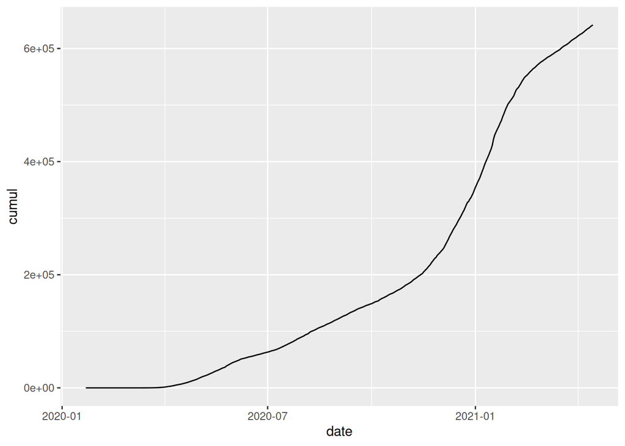

```r
# Cumulative plot!
# Not what we want.
cases %>% filter(state=="Virginia") %>%
  ggplot(aes(x=date,y=cumul)) +
  geom_line()
```

```r
first_diff <- function(arr){
  to_return <- NULL
  for (i in 2:length(arr)){
   to_return[i] <- arr[i] - arr[i-1]
  }
  return(to_return)
}

add_firstdiff <- function(df){
  unique_states <- unique(df$state)
  dfs <- list()
  for (this_state in unique_states){
    thisdf <- df %>% filter(state==this_state)
    thisdf$diff <- first_diff(thisdf$cumul)
    dfs[[length(dfs) + 1]] <- thisdf
  }
  return(dfs %>% reduce(full_join))
}
```

```r
cases <- add_firstdiff(cases) %>%
  select(date,state,diff) %>%
  rename(c("positiveIncrease"="diff"))
deaths <- add_firstdiff(deaths) %>%
  select(date,state,diff) %>%
  rename(c("deathIncrease"="diff"))

data <- left_join(cases,deaths,by=c("date","state")) %>%
  mutate(state=tolower(state)) %>%
  filter(date >= date("2020-02-01"))
```

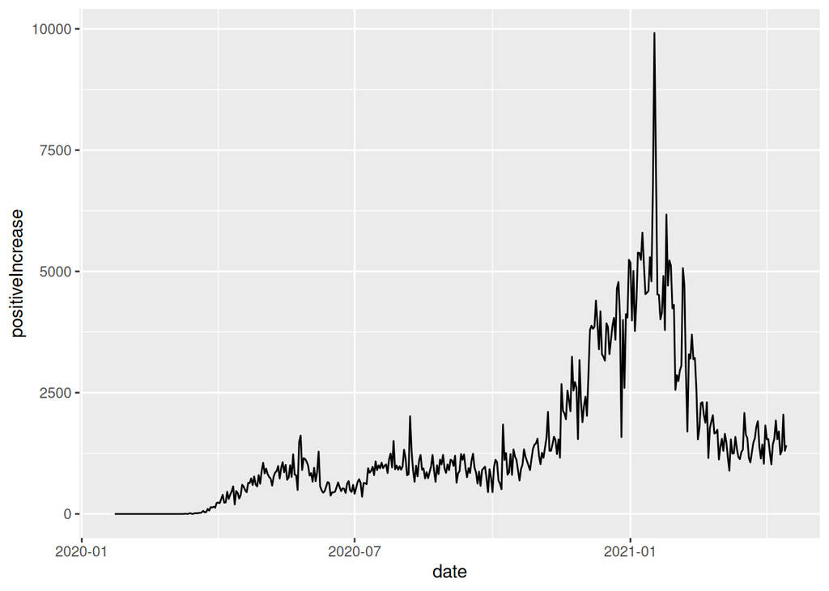

```r
# Our difference function worked!
cases %>% filter(state=="Virginia") %>%
  ggplot(aes(x=date,y=positiveIncrease)) +
  geom_line()
```

- We want to get the dates that our plots will range over.
  - We’ll generate one plot for each month of the pandemic. So use `seq` to interpolate between the earliest date and the latest date by months.
  - The last date is manually added (it might not be a full month to the last date in the data frame) so that we can also incorporate the most recent information as well.
- We want to generate a set of intervals (ordered pairs) of months, e.g from Jan to Feb, Feb to Mar, Mar to Apr..
  - A simple for-loop takes care of this and stores the info in `intervals`.

```r
dates <- seq(min(data$date),max(data$date),by="months")
dates <- dates %>% append(max(data$date))

intervals <- list()
for (i in 2:length(dates)){
  intervals[[i-1]] <- c(dates[i-1],dates[i])
}
```

- R has built-in geographical data that represents each state as a set of polygons by lat and long.
  - We will use this to plot the US map.

```r
states_map <- map_data("state")
```

- Here are the functions that plot a map for one specific interval.
  - It works by filtering out all observations in the data in that interval, grouping by state, and then getting the cumulative increase in each state over that interval of time.
  - Then, that data is joined with the map data to produce a plot using ggplot.
  - The gradient scale is then set at an absolute number to ensure that the scale is consistent across all plots produced.
    - This will make sure we can compare maps across time.
  - The map is titled accordingly using the `paste` function so we know which date interval it is.
  - The plot is cleaned by removing some unnecessary elements.

```r
heatmap_for_givenday_deathIncrease <- function(interval){
  cumul_increase <- data %>%
    filter(between(date,interval[1],interval[2])) %>%
    group_by(state) %>%
    summarize(total=sum(deathIncrease))
  #cumul_increase$statename <-  tolower(state.name[match(cumul_increase$state,state.abb)])
  loc_data <- left_join(states_map,cumul_increase,by=c("region"="state"))
  # Used to see the max value in order to set the gradient.
  #print(max(cumul_increase$total))
  p <- loc_data %>%
    ggplot() +
    geom_polygon(aes(x=long,y=lat,group=group,fill=total),color="grey") +
    scale_fill_gradient(low="white",high="red", limits=c(0,22136)) +
    ggtitle(paste("New deaths: ",interval[1]," to ",interval[2])) +
    theme(axis.title=element_blank(),
          axis.ticks=element_blank(),
          panel.grid=element_blank(),
          axis.text.x = element_blank(),
          axis.text.y = element_blank())
  return(p)
}

heatmap_for_givenday_positiveIncrease <- function(interval){
  cumul_increase <- data %>%
    filter(between(date,interval[1],interval[2])) %>%
    group_by(state) %>%
    summarize(total=sum(positiveIncrease))
  #cumul_increase$statename <-  tolower(state.name[match(cumul_increase$state,state.abb)])
  loc_data <- left_join(states_map,cumul_increase,by=c("region"="state"))
  #loc_data <- left_join(states_map,cumul_increase,by=c("region"="statename"))

  # Used to see the max value in order to set the gradient.
  #print(max(cumul_increase$total))


  p <- loc_data %>%
    ggplot() +
    geom_polygon(aes(x=long,y=lat,group=group,fill=total),color="grey") +
    #scale_fill_gradient(low="white",high="red",limits=c(0,1259607)) +
    scale_fill_gradient(low="white",high="red",limits=c(0,1259607)) +
    ggtitle(paste("New cases: ",interval[1]," to ",interval[2])) +
        theme(axis.title=element_blank(),
          axis.ticks=element_blank(),
          panel.grid=element_blank(),
          axis.text.x = element_blank(),
          axis.text.y = element_blank())
  return(p)
}
```

- We can use `map` from `purrr` to apply our function readily across our list of intervals, making the process of generating each plot very straightforward.
  - A sample plot is displayed below (there are too many to include in this document).
  - They are exported by running each line again manually.

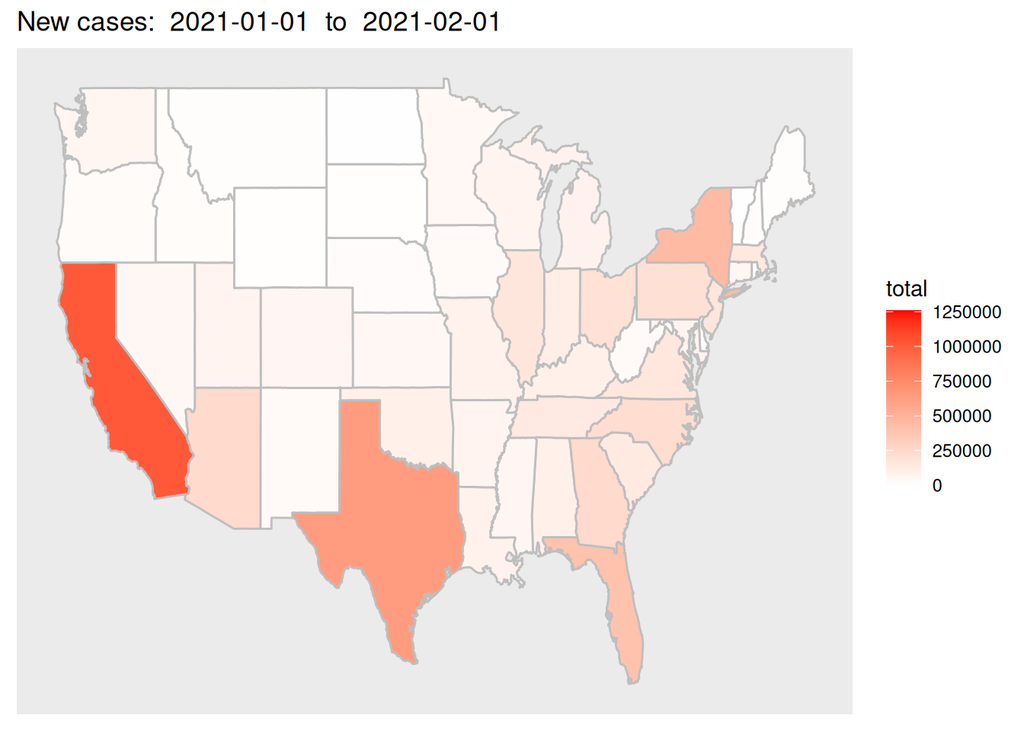

```r
plots <- map(intervals,heatmap_for_givenday_deathIncrease)
plots <- map(intervals,heatmap_for_givenday_positiveIncrease)
plots[[12]]
```

- These maps can be exported batch-by-batch using the code below.

```r
for (i in 1:length(plots)){
  ggsave(plot=plots[[i]],path="../project/out",filename=paste("cases",i,".png",sep=""),width=5,height=4,device="png")
}
```

- `ffmpeg` was then used to join the images together into a video.
  - The command needed to be adjusted slightly from batch to batch.

```bash
ffmpeg -r 1 -f image2 -s 1920x1080 -i ../deaths/project/out/cases/cases%d.png -vcodec libx264 -crf 25 -pix_fmt yuv420p test.mp4
```

- The videos cannot be embedded into a PDF,
- This whole procedure can also be replicated for each region of the US, giving us a better idea of regional trends as well.
  - A csv containing the region names for each state is imported and joined with the data.

```r
us_regions <- read_csv("https://raw.githubusercontent.com/cphalpert/census-regions/master/us%20census%20bureau%20regions%20and%20divisions.csv")

data <- left_join(cases,deaths) %>%
  filter(date >= date("2020-02-01"))

data <- left_join(data,us_regions,by=c("state"="State"))
```

- The functions are adjusted slightly to allow filtering by region.
  - An `upbound` argument is added to make it easier to set the absolute scale of the gradient.

```r
heatmap_for_givenday_positiveIncrease <- function(interval,region,upbound){
  cumul_increase <- data %>%
    filter(Region == region) %>%
    filter(between(date,interval[1],interval[2])) %>%
    group_by(state) %>% #added when JHU data used
    mutate(state=tolower(state)) %>%
    summarize(total=sum(positiveIncrease))
  #cumul_increase$statename <-  tolower(state.name[match(cumul_increase$state,state.abb)])
  #loc_data <- inner_join(states_map,cumul_increase,by=c("region"="statename"))
  loc_data <- inner_join(states_map,cumul_increase,by=c("region"="state"))

  #print(max(cumul_increase$total))

  p <- loc_data %>%
    ggplot() +
    geom_polygon(aes(x=long,y=lat,group=group,fill=total),color="grey") +
    scale_fill_gradient(low="white",high="red",limits=c(0,upbound)) +
    ggtitle(paste(region,"- New cases: ",interval[1]," to ",interval[2])) +
        theme(axis.title=element_blank(),
          axis.ticks=element_blank(),
          panel.grid=element_blank(),
          axis.text.x = element_blank(),
          axis.text.y = element_blank())
  return(p)
}

heatmap_for_givenday_deathIncrease <- function(interval,region,upbound){
  cumul_increase <- data %>%
    filter(Region == region) %>%
    filter(between(date,interval[1],interval[2])) %>%
    group_by(state) %>%
    mutate(state=tolower(state)) %>%
    summarize(total=sum(deathIncrease))
  #cumul_increase$statename <-  tolower(state.name[match(cumul_increase$state,state.abb)])
  #loc_data <- inner_join(states_map,cumul_increase,by=c("region"="statename"))
  loc_data <- inner_join(states_map,cumul_increase,by=c("region"="state"))

  print(max(cumul_increase$total))

  p <- loc_data %>%
    ggplot() +
    geom_polygon(aes(x=long,y=lat,group=group,fill=total),color="grey") +
    scale_fill_gradient(low="white",high="red",limits=c(0,upbound)) +
    ggtitle(paste(region,"- New deaths: ",interval[1]," to ",interval[2])) +
        theme(axis.title=element_blank(),
          axis.ticks=element_blank(),
          panel.grid=element_blank(),
          axis.text.x = element_blank(),
          axis.text.y = element_blank())
  return(p)
}
```

- The maps are once again generated in a very similar procedure.
  - Below is an example regional map.

```r
plots <- map(intervals,heatmap_for_givenday_positiveIncrease,"South",639843)
plots <- map(intervals,heatmap_for_givenday_positiveIncrease,"West",1259607)
plots <- map(intervals,heatmap_for_givenday_positiveIncrease,"Northeast",404981)
plots <- map(intervals,heatmap_for_givenday_positiveIncrease,"Midwest",312362)

plots <- map(intervals,heatmap_for_givenday_deathIncrease,"South",10159)
plots <- map(intervals,heatmap_for_givenday_deathIncrease,"West",15922)
plots <- map(intervals,heatmap_for_givenday_deathIncrease,"Northeast",22136)
plots <- map(intervals,heatmap_for_givenday_deathIncrease,"Midwest",6538)
```

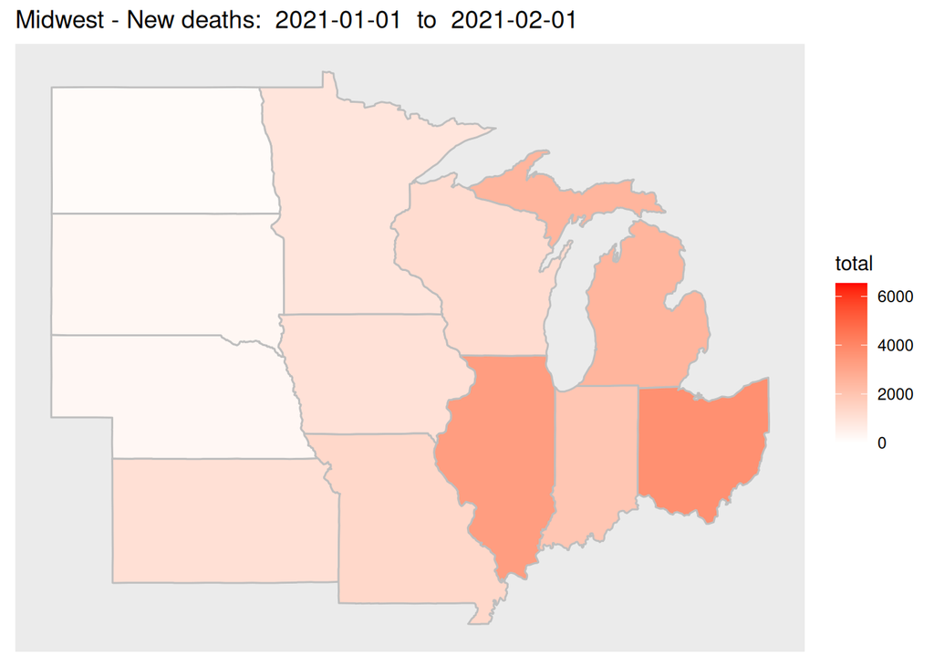

```r
plots[[12]]
```

- A similar code and bash command is used to generate animations.

```r
for (i in 1:length(plots)){
  ggsave(plot=plots[[i]],path="../project/out",filename=paste("midwest_death",i,".png",sep=""),width=5,height=4,device="png")
}
```

- National cases:

[video not shown]

- National deaths:

[video not shown]

- Midwest cases

[video not shown]

- Midwest deaths

[video not shown]

- Northeast cases

[video not shown]

- Northeast deaths

[video not shown]

- South cases

[video not shown]

- South deaths

[video not shown]

- West cases

[video not shown]

- West deaths

[video not shown]

## Discussion and highlights

Ranking regions by record high monthly case volume in ascending order,

[output not shown]

Investigating hotspots by region,

- South
  - Florida and Texas are hotspots of the South
- West
  - California and Arizona
- Northeast
  - New York and Pennsylvania
- Midwest
  - Ohio, Illinois

Deaths map: - 2020-03-13 to 2020-04-13 - New York has the worst count of deaths by far. Other states in the Northeast, California are seeing rises as well. - Deaths continue to worsen in New York through the next month.

- 2020-05-13 to 2020-06-13
  - Deaths are reduced from the last month, however the Northeast, California, Illinois are still standing out.
  - Overall deaths have increased in other states.
- 2020-07-13 to 2020-08-13
  - Deaths begin to increase in the South, especially Florida and Texas.
  - Arizona, California, Nevada see increases in deaths.

- From 10-2020 to 1-2021, we see especially large nationwide increases.
  - California sees especially large increases in cases and deaths, followed by Texas and Florida.
  - Ohio, illinois, New York, and most of the Northeast and South also see increases.
- Cases and deaths taper on the last couple available months of the dataset (but may be due to lack of data availability.)

Qualitatively speaking, the deaths and the cases charts coincide quite well. - It is known that there is a “lag time” between increases in cases and increases in deaths. This may be due to the time required to report the data as well as the time required for cases to develop. - This is especially evident from December 2020 to January 2021. The cases hit their peak in California in December, but the deaths do not peak until the month after, even though new cases in California go down during that period.